`title: "Learning By Building : Optimizing Logistics Distribution Routes: A Graph Theory Approach"`

`author: "Dedy Gusnadi Sianipar"`

`date: 29 June 2023`

# LBB Rubrics

## Rubrics

Outline:

1. Import Library dan Data
2. Data Preprocessing & Feature Engineering: Create weight from Total Cost
3. Pembentukan Graph dan Visualisasi Graf
4. Pencarian Rute Optimal
5. [Optional] Visualisasi Rute Baru
6. [Optional] Travelling Salesman Problem (TSP)

# Library

```python
import pandas as pd # manipulating data
import datetime # manipulating datetme format
from helper import graph # visualisasi
```

## Dataset

Dataset berikut adalah data yang berisi tentang pengiriman suatu makan dingin di Makassar. Dimana terdapat 2 data yaitu `records_mks`, dan `lokasi_makassar` yang berisi informasi pengiriman antar lokasinya.

```python
import pandas as pd

raw_data=pd.read_csv('records_mks.csv')
raw_data.head(6)
```

|  | start | end | lokasi_start | latitude_start | longitude_start | lokasi_end | latitude_end | longitude_end | dist | lge/100km | add_cost | start_time | end_time |
| --- | --- | --- | --- | --- | --- | --- | --- | --- | --- | --- | --- | --- | --- |
| 0 | B | D | Nipah Mall | -5.138213 | 119.450386 | Mall Ratu Indah | -5.152877 | 119.417858 | 7.5 | 15.08 | 0.0 | 2023-05-03 15:20:00 | 2023-05-03 15:45:00 |
| 1 | A | B | Warehouse | -5.094272 | 119.491642 | Nipah Mall | -5.138213 | 119.450386 | 11.0 | 13.52 | 15.5 | 2023-05-03 14:19:00 | 2023-05-03 14:44:00 |
| 2 | F | G | Makassar Town Square | -5.139702 | 119.473848 | Phinisi Point | -5.151032 | 119.404404 | 12.3 | 16.03 | 0.0 | 2023-05-02 15:10:00 | 2023-05-02 15:48:00 |
| 3 | A | F | Warehouse | -5.094272 | 119.491642 | Makassar Town Square | -5.139702 | 119.473848 | 9.7 | 14.45 | 0.0 | 2023-05-02 14:13:00 | 2023-05-02 14:39:00 |
| 4 | E | C | Mall Panakkukang | -5.156903 | 119.446034 | TSM Makassar | -5.158039 | 119.394943 | 9.8 | 15.27 | 0.0 | 2023-05-01 15:02:00 | 2023-05-01 15:33:00 |
| 5 | A | E | Warehouse | -5.094272 | 119.491642 | Mall Panakkukang | -5.156903 | 119.446034 | 14.2 | 12.72 | 15.5 | 2023-05-01 14:02:00 | 2023-05-01 14:28:00 |

```python
lokasi=pd.read_csv("lokasi_makassar.csv")
lokasi.head(5)
```

|  | kode | lokasi | latitude | longitude |
| --- | --- | --- | --- | --- |
| 0 | A | Warehouse | -5.094272 | 119.491642 |
| 1 | B | Nipah Mall | -5.138213 | 119.450386 |
| 2 | C | TSM Makassar | -5.158039 | 119.394943 |
| 3 | D | Mall Ratu Indah | -5.152877 | 119.417858 |
| 4 | E | Mall Panakkukang | -5.156903 | 119.446034 |

**Deskripsi Data:**

Data `records_mks` merupakan kumpulan catatan pengiriman distribusi. Berikut informasi dari setiap kolom:

- `start`: Lokasi berangkat
- `end`: Lokasi tujuan
- `lokasi_start`: Nama lokasi awal
- `latitude_start`: Titik latitude lokasi awal
- `longitude_start`: Titik longitude lokasi awal
- `lokasi_end`: Nama lokasi tujuan
- `latitude_end`: Titik latitude lokasi tujuan
- `longitude_end`: Titik longitude lokasi tujuan
- `dist`: Jarak tempuh (satuan km)
- `lge/100km`: Penggunaan liter bensin / 100 km
- `add_cost`: Tambahan biaya dalam satuan Ribu Rupiah (Biaya Tol)
- `start_time`: Waktu berangkat
- `end_time`: Waktu tiba

**Deskripsi Data:**

Data `lokasi_makassar` merupakan database kumpulan lokasi. Berikut informasi dari setiap kolom:

- `kode`: Kode Lokasi
- `lokasi`: Nama lokasi
- `latitude`: Titik latitude lokasi
- `longitude`: Titik longitude lokasi

# Data Preprocessing & Data Cleaning

```python
#copy data
df_rec = raw_data.copy()
df_loc = lokasi.copy()
```

```python
# check tipe data
df_rec.dtypes
```

```
start               object
end                 object
lokasi_start        object
latitude_start     float64
longitude_start    float64
lokasi_end          object
latitude_end       float64
longitude_end      float64
dist               float64
lge/100km          float64
add_cost           float64
start_time          object
end_time            object
dtype: object
```

```
dikarenakan ada beberapa kolom yang belum sesuai dengan tipe datanya , maka kita ganti menjadi tipe data yang sesuai:
```

- `start , end , lokasi_start , lokasi_end` :`category`
- `start_time , end_time` :`datetime64[ns]`

```python
df_rec[['start','lokasi_start','end', 'lokasi_end']]= df_rec[['start','lokasi_start','end','lokasi_end']].astype('category')
df_rec[['start_time','end_time']] =df_rec[['start_time','end_time']].astype('datetime64[ns]')
```

Menambahkan Kolom `day` , `month_name` , `week_period` dan `weekofyear` , untuk mempermudah menganalisis data

```python
df_rec['day'] = df_rec['start_time'].dt.day_name()
df_rec['month_name']=df_rec['start_time'].dt.month_name()
df_rec['week_period']=df_rec['start_time'].dt.to_period('W')
df_rec['weekofyear'] = df_rec['start_time'].dt.isocalendar().week
```

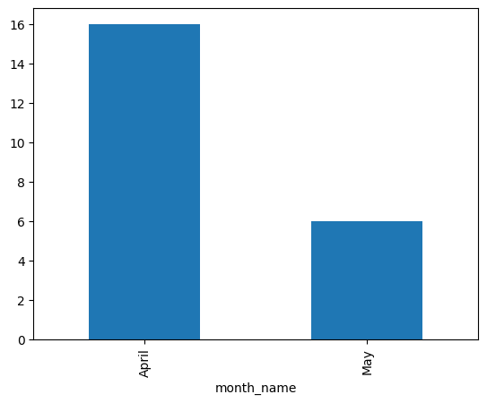

```python
df_rec['month_name'].value_counts().plot(kind = 'bar')
```

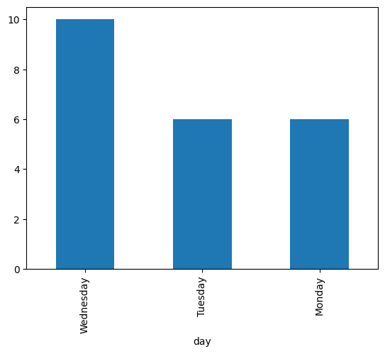

```python
df_rec['day'].value_counts().plot(kind = 'bar')
```

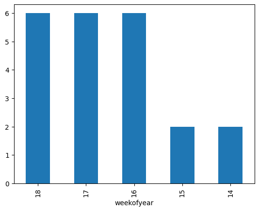

```python
df_rec['weekofyear'].value_counts().plot(kind = 'bar')
```

> Note:
> - Dari data kita bisa dilihat bahwa terdapat aktifitas pengiriman lebih banyak dibulan april dibanding may
> - Pengiriman hanya terjadi di hari Senin, Selasa dan juga Rabu, dimana pengiriman di hari rabu lebih banyak dibanding senin dan selasa
> - Di pekan ke-16 hingga pekan ke-18 pengiriman paling banyak terjadi (dibanding pekan ke-14 dan ke-15)

```python
week18 = df_rec[df_rec['weekofyear'] == 18].sort_values(by = 'start_time')

week18
```

|  | start | end | lokasi_start | latitude_start | longitude_start | lokasi_end | latitude_end | longitude_end | dist | lge/100km | add_cost | start_time | end_time | day | month_name | week_period | weekofyear |
| --- | --- | --- | --- | --- | --- | --- | --- | --- | --- | --- | --- | --- | --- | --- | --- | --- | --- |
| 5 | A | E | Warehouse | -5.094272 | 119.491642 | Mall Panakkukang | -5.156903 | 119.446034 | 14.2 | 12.72 | 15.5 | 2023-05-01 14:02:00 | 2023-05-01 14:28:00 | Monday | May | 2023-05-01/2023-05-07 | 18 |
| 4 | E | C | Mall Panakkukang | -5.156903 | 119.446034 | TSM Makassar | -5.158039 | 119.394943 | 9.8 | 15.27 | 0.0 | 2023-05-01 15:02:00 | 2023-05-01 15:33:00 | Monday | May | 2023-05-01/2023-05-07 | 18 |
| 3 | A | F | Warehouse | -5.094272 | 119.491642 | Makassar Town Square | -5.139702 | 119.473848 | 9.7 | 14.45 | 0.0 | 2023-05-02 14:13:00 | 2023-05-02 14:39:00 | Tuesday | May | 2023-05-01/2023-05-07 | 18 |
| 2 | F | G | Makassar Town Square | -5.139702 | 119.473848 | Phinisi Point | -5.151032 | 119.404404 | 12.3 | 16.03 | 0.0 | 2023-05-02 15:10:00 | 2023-05-02 15:48:00 | Tuesday | May | 2023-05-01/2023-05-07 | 18 |
| 1 | A | B | Warehouse | -5.094272 | 119.491642 | Nipah Mall | -5.138213 | 119.450386 | 11.0 | 13.52 | 15.5 | 2023-05-03 14:19:00 | 2023-05-03 14:44:00 | Wednesday | May | 2023-05-01/2023-05-07 | 18 |
| 0 | B | D | Nipah Mall | -5.138213 | 119.450386 | Mall Ratu Indah | -5.152877 | 119.417858 | 7.5 | 15.08 | 0.0 | 2023-05-03 15:20:00 | 2023-05-03 15:45:00 | Wednesday | May | 2023-05-01/2023-05-07 | 18 |

Rute di minggu ke 18 pada hari:

- `Senin` = `AEC` `Warehouse - Mall Panakkukang - TSM Makassar`
- `Selasa` = `AFG` `Warehouse - Makassar Town Square - Phinisi Point`
- `Rabu` = `ABD` `Warehouse - Nipah Mall - Mall Ratu Indah`

Kita Coba Lihat Menggunakan Visualisasi dari Modul Helper

```python
map_df = graph.create_map_object('Makassar, Indonesia')
```

```python
# Visualisasi koordinat utk week 18
graph.visualize_route(map_df, week18)
```

Make this Notebook Trusted to load map: File -> Trust Notebook

[interactive chart not shown]

Make this Notebook Trusted to load map: File -> Trust Notebook

[interactive chart not shown]

Make this Notebook Trusted to load map: File -> Trust Notebook

[interactive chart not shown]

```python
# Visualisasi untuk week 17
week17 = df_rec[df_rec['weekofyear'] == 17].sort_values(by = 'start_time')

graph.visualize_route(map_df, week17)
```

Make this Notebook Trusted to load map: File -> Trust Notebook

[interactive chart not shown]

Make this Notebook Trusted to load map: File -> Trust Notebook

[interactive chart not shown]

Make this Notebook Trusted to load map: File -> Trust Notebook

[interactive chart not shown]

# Teori Graph

Teori graf adalah sebuah konsep matematika di mana digunakan untuk memodelkan hubungan antar objek. Hubungan ini direpresentasikan ke dalam sebuah **graf**.

Contoh implementasi teori graf yaitu:

- Optimalisasi rute, seperti rute pengiriman (yang dibahas notebook ini)
- Pemodelan jaringan yang kompleks, seperti jaringan sosial (*social networks*)
- Pemodelan penyebaran penyakit menular, seperti Covid.

Untuk memodelkan hubungan antar objek, Graf terdiri dari komponen **nodes** yang menyatakan objek dan **edges** yang menyatakan hubungan antar objek. Mari kita telaah lebih dalam mengenai **nodes** dan **edges**

# Networkx

Setelah mengetahui intuisi dari teori graf, selanjutnya kita akan menerapkan teori graf di python menggunakan library `networkx`.

`networkx` adalah salah satu *package*/*library* pada Python yang berfungsi untuk mengeksplorasi dan menganalisis graf dan algoritma graf. Networkx menyediakan berbagai jenis graf untuk menggambarkan jaringan termasuk *weighted* dan *unweighted graph*.

> Lebih lengkapnya silahkan kunjungi [official documentation](https://networkx.org/documentation/latest/reference/index.html)

Untuk menggunakan `networkx`, kita perlu import terlebih dahulu library dengan cara berikut ini:

```python
import networkx as nx
print(nx.__version__)
```

```
3.1
```

# Studi Kasus

## BATASAN MASALAH

Selain informasi dari data ini, kita juga mengetahui beberapa informasi antara lain:

**Aturan**

- A (warehouse) adalah pusat penyimpanan. Setiap jalur distribusi berawal dari titik A
- Kebutuhan produk perminggu setiap lokasi adalah 1 ton.
- Truk dapat mengangkut produk dengan berat maksimal 2,2 ton.
- Waktu drop di setiap lokasi adalah -+ 30 menit

**Biaya:**

- Bahan bakar yang digunakan truk adalah Dexlite (Rp14,950/liter)
- Biaya pengeluaran mesin pendingin truk adalah Rp9,000/jam

> ⚠ Disclaimer: Bisnis problem dan data bersifat *dummy* yang terinspirasi dari hasil penelitian Liang, Wu dan Sun <sup>[[2](https://doi.org/10.2991/asei-15.2015.145)]</sup> dimana mencari rute optimal pada kasus cold chain logistics menggunakan Particle Swarm Optimization (PSO). Inspirasi lain juga berasal dari artikel Samir Saci <sup>[[3](https://towardsdatascience.com/transportation-network-analysis-with-graph-theory-55eceb7e4de4)]</sup> yang melakukan analisis jaringan distribusi menggunakan Teori Graf.

## Solution

💡 Merepresentasikan `records` ke dalam `Graf` kemudian mencari rute-rute dengan `weight` terendah.

💡 `weight` bisa dalam bentuk total biaya (cost) yang dikeluarkan masing-masing rutenya.

💡 Total cost dapat diektrak dari data `records` dengan informasi-informasi yang kita ketahui.

💬 **Informasi apa saja yang dapat digunakan untuk mendapatkan biaya?**

- 💡 `add_cost`
- 💡 `dist` (jarak), `lge/100km` (bahan bakar), dan harga bensin dapat digunakan untuk mencari biaya bahan bakar
- 💡 Informasi waktu dapat digunakan untuk mencari biaya pengeluaran pendingin truk.
- 💡 Total biaya-biaya tersebut akan menjadi `weight` pada setiap `edges graf`

## Pre-processing & Feature Engineering

### Biaya Bensin

Informasi yang dapat digunakan:

- kolom `dist`, menyatakan jarak dalam satuan km.
- kolom `lge/100km`, menyatakan penggunaan liter bensin / 100 km.
- Truk di perusahaan kita menggunakan bensin Dexlite seharga Rp14,950/liter

💡 Langkah:

- Hitung penggunaan liter bahan bakar dengan formula:

  $ literneed = lge/100km \times \frac{dist}{100}$
- Penggunaan liter akan dikalikan dengan biaya bensin/liter.

  $ costfuel = literneed \times dexlitecost $

> Additional Notes: Semakin besar nilai lge/100km maka semakin boros bensin untuk rute tersebut. Hal ini dapat dipengaruhi oleh tingkat kemacetan jalanan dimana penggunaan bahan bakar dapat meningkat 90-170% dari konsumsi normal bensin <sup>[[4](https://www.viamichelin.com/magazine/article/traffic-jams-our-tips-for-saving-fuel/#:~:text=An%20idling%20vehicle%20uses%20about,and%20175%25%20in%20urban%20areas)]</sup>.

```python
# Harga dexlite dalam satuan ribu
fuel = 14.95
# Mendapatkan total liter
df_rec['literneed'] = df_rec['lge/100km'] * (df_rec['dist'] / 100)

df_rec['cost_fuel'] = df_rec['literneed'] * fuel

df_rec.head(5)
```

|  | start | end | lokasi_start | latitude_start | longitude_start | lokasi_end | latitude_end | longitude_end | dist | lge/100km | add_cost | start_time | end_time | day | month_name | week_period | weekofyear | literneed | cost_fuel |
| --- | --- | --- | --- | --- | --- | --- | --- | --- | --- | --- | --- | --- | --- | --- | --- | --- | --- | --- | --- |
| 0 | B | D | Nipah Mall | -5.138213 | 119.450386 | Mall Ratu Indah | -5.152877 | 119.417858 | 7.5 | 15.08 | 0.0 | 2023-05-03 15:20:00 | 2023-05-03 15:45:00 | Wednesday | May | 2023-05-01/2023-05-07 | 18 | 1.13100 | 16.908450 |
| 1 | A | B | Warehouse | -5.094272 | 119.491642 | Nipah Mall | -5.138213 | 119.450386 | 11.0 | 13.52 | 15.5 | 2023-05-03 14:19:00 | 2023-05-03 14:44:00 | Wednesday | May | 2023-05-01/2023-05-07 | 18 | 1.48720 | 22.233640 |
| 2 | F | G | Makassar Town Square | -5.139702 | 119.473848 | Phinisi Point | -5.151032 | 119.404404 | 12.3 | 16.03 | 0.0 | 2023-05-02 15:10:00 | 2023-05-02 15:48:00 | Tuesday | May | 2023-05-01/2023-05-07 | 18 | 1.97169 | 29.476766 |
| 3 | A | F | Warehouse | -5.094272 | 119.491642 | Makassar Town Square | -5.139702 | 119.473848 | 9.7 | 14.45 | 0.0 | 2023-05-02 14:13:00 | 2023-05-02 14:39:00 | Tuesday | May | 2023-05-01/2023-05-07 | 18 | 1.40165 | 20.954667 |
| 4 | E | C | Mall Panakkukang | -5.156903 | 119.446034 | TSM Makassar | -5.158039 | 119.394943 | 9.8 | 15.27 | 0.0 | 2023-05-01 15:02:00 | 2023-05-01 15:33:00 | Monday | May | 2023-05-01/2023-05-07 | 18 | 1.49646 | 22.372077 |

## Biaya Pendingin

Informasi yang dapat digunakan:

- Biaya maintain pendingin truk perjam (Rp9,000/jam)
- `start_time` dan `end_time` untuk mendapatkan waktu menit perjalanan

💡 Langkah:

- Dapatkan menit perjalanan dengan `end_time` - `start_time`.
- Kalikan total menit dengan biaya maintain pendingin.

  $ costrefri = totalminutes \times \frac{refrigeratorcost}{60} $

Pada datetime dapat dilakukan subtraksi datetime seperti di bawah ini

```python
# Masukkan total minutes ke dalam kolom time, total second / 60 untuk mendapatkan menit
df_rec['time'] = (df_rec['end_time'] - df_rec['start_time']).dt.total_seconds() / 60

# Biaya pendingin/jam dalam satuan ribu
refrigerator = 9
# total cost refri
df_rec['cost_refri'] = (df_rec['time']  / 60) * refrigerator

df_rec.head(2)
```

|  | start | end | lokasi_start | latitude_start | longitude_start | lokasi_end | latitude_end | longitude_end | dist | lge/100km | ... | start_time | end_time | day | month_name | week_period | weekofyear | literneed | cost_fuel | time | cost_refri |
| --- | --- | --- | --- | --- | --- | --- | --- | --- | --- | --- | --- | --- | --- | --- | --- | --- | --- | --- | --- | --- | --- |
| 0 | B | D | Nipah Mall | -5.138213 | 119.450386 | Mall Ratu Indah | -5.152877 | 119.417858 | 7.5 | 15.08 | ... | 2023-05-03 15:20:00 | 2023-05-03 15:45:00 | Wednesday | May | 2023-05-01/2023-05-07 | 18 | 1.1310 | 16.90845 | 25.0 | 3.75 |
| 1 | A | B | Warehouse | -5.094272 | 119.491642 | Nipah Mall | -5.138213 | 119.450386 | 11.0 | 13.52 | ... | 2023-05-03 14:19:00 | 2023-05-03 14:44:00 | Wednesday | May | 2023-05-01/2023-05-07 | 18 | 1.4872 | 22.23364 | 25.0 | 3.75 |

2 rows × 21 columns

## Total Cost

Total cost akan kita jadikan sebagai `weight` dalam Graf kita nantinya. Sehingga kita akan mendapatkan kombinasi masing-masing rute beserta total biayanya.

Informasi yang digunakan:

- `cost_fuel`: total biaya bahan bakar
- `cost_refri`: total biaya maintain pendingin
- `add_cost`: *additional_cost*, dalam hal ini adalah biaya tol

💡 Langkah:

Menjumlahkan masing-masing cost

$ total = costfuel + costrefri + addcost $

```python
df_rec['total'] = df_rec['cost_fuel'] + df_rec['cost_refri'] + df_rec['add_cost']

df_rec.head(2)
```

|  | start | end | lokasi_start | latitude_start | longitude_start | lokasi_end | latitude_end | longitude_end | dist | lge/100km | ... | end_time | day | month_name | week_period | weekofyear | literneed | cost_fuel | time | cost_refri | total |
| --- | --- | --- | --- | --- | --- | --- | --- | --- | --- | --- | --- | --- | --- | --- | --- | --- | --- | --- | --- | --- | --- |
| 0 | B | D | Nipah Mall | -5.138213 | 119.450386 | Mall Ratu Indah | -5.152877 | 119.417858 | 7.5 | 15.08 | ... | 2023-05-03 15:45:00 | Wednesday | May | 2023-05-01/2023-05-07 | 18 | 1.1310 | 16.90845 | 25.0 | 3.75 | 20.65845 |
| 1 | A | B | Warehouse | -5.094272 | 119.491642 | Nipah Mall | -5.138213 | 119.450386 | 11.0 | 13.52 | ... | 2023-05-03 14:44:00 | Wednesday | May | 2023-05-01/2023-05-07 | 18 | 1.4872 | 22.23364 | 25.0 | 3.75 | 41.48364 |

2 rows × 22 columns

```python
# code here
df_rec.sort_values(by = 'total', ascending = False).head(5)
```

|  | start | end | lokasi_start | latitude_start | longitude_start | lokasi_end | latitude_end | longitude_end | dist | lge/100km | ... | end_time | day | month_name | week_period | weekofyear | literneed | cost_fuel | time | cost_refri | total |
| --- | --- | --- | --- | --- | --- | --- | --- | --- | --- | --- | --- | --- | --- | --- | --- | --- | --- | --- | --- | --- | --- |
| 9 | A | C | Warehouse | -5.094272 | 119.491642 | TSM Makassar | -5.158039 | 119.394943 | 18.0 | 14.27 | ... | 2023-04-25 14:42:00 | Tuesday | April | 2023-04-24/2023-04-30 | 17 | 2.56860 | 38.400570 | 41.0 | 6.15 | 60.050570 |
| 11 | A | G | Warehouse | -5.094272 | 119.491642 | Phinisi Point | -5.151032 | 119.404404 | 15.8 | 14.90 | ... | 2023-04-24 14:49:00 | Monday | April | 2023-04-24/2023-04-30 | 17 | 2.35420 | 35.195290 | 39.0 | 5.85 | 56.545290 |
| 15 | A | D | Warehouse | -5.094272 | 119.491642 | Mall Ratu Indah | -5.152877 | 119.417858 | 15.6 | 14.55 | ... | 2023-04-18 14:40:00 | Tuesday | April | 2023-04-17/2023-04-23 | 16 | 2.26980 | 33.933510 | 38.0 | 5.70 | 55.133510 |
| 5 | A | E | Warehouse | -5.094272 | 119.491642 | Mall Panakkukang | -5.156903 | 119.446034 | 14.2 | 12.72 | ... | 2023-05-01 14:28:00 | Monday | May | 2023-05-01/2023-05-07 | 18 | 1.80624 | 27.003288 | 26.0 | 3.90 | 46.403288 |
| 17 | A | E | Warehouse | -5.094272 | 119.491642 | Mall Panakkukang | -5.156903 | 119.446034 | 14.2 | 12.72 | ... | 2023-04-17 14:31:00 | Monday | April | 2023-04-17/2023-04-23 | 16 | 1.80624 | 27.003288 | 26.0 | 3.90 | 46.403288 |

5 rows × 22 columns

Tujuan utama kita adalah mencari rute dengan weight paling minimum (optimal).

Pertanyaan: weightnya dalam bentuk apa?

- Total Cost -> Total biaya per-rute.
- Total Biaya = Biaya bensin + Biaya pendingin + Addition Cost (Tol)

## Drop Duplicates

```python
    # Drop duplikat untuk data lama (pertahankan data terbaru)
df_rec_new = df_rec.drop_duplicates(subset = ['start', 'end'], keep = 'first')
df_rec_new.head()
```

|  | start | end | lokasi_start | latitude_start | longitude_start | lokasi_end | latitude_end | longitude_end | dist | lge/100km | ... | end_time | day | month_name | week_period | weekofyear | literneed | cost_fuel | time | cost_refri | total |
| --- | --- | --- | --- | --- | --- | --- | --- | --- | --- | --- | --- | --- | --- | --- | --- | --- | --- | --- | --- | --- | --- |
| 0 | B | D | Nipah Mall | -5.138213 | 119.450386 | Mall Ratu Indah | -5.152877 | 119.417858 | 7.5 | 15.08 | ... | 2023-05-03 15:45:00 | Wednesday | May | 2023-05-01/2023-05-07 | 18 | 1.13100 | 16.908450 | 25.0 | 3.75 | 20.658450 |
| 1 | A | B | Warehouse | -5.094272 | 119.491642 | Nipah Mall | -5.138213 | 119.450386 | 11.0 | 13.52 | ... | 2023-05-03 14:44:00 | Wednesday | May | 2023-05-01/2023-05-07 | 18 | 1.48720 | 22.233640 | 25.0 | 3.75 | 41.483640 |
| 2 | F | G | Makassar Town Square | -5.139702 | 119.473848 | Phinisi Point | -5.151032 | 119.404404 | 12.3 | 16.03 | ... | 2023-05-02 15:48:00 | Tuesday | May | 2023-05-01/2023-05-07 | 18 | 1.97169 | 29.476766 | 38.0 | 5.70 | 35.176766 |
| 3 | A | F | Warehouse | -5.094272 | 119.491642 | Makassar Town Square | -5.139702 | 119.473848 | 9.7 | 14.45 | ... | 2023-05-02 14:39:00 | Tuesday | May | 2023-05-01/2023-05-07 | 18 | 1.40165 | 20.954667 | 26.0 | 3.90 | 24.854667 |
| 4 | E | C | Mall Panakkukang | -5.156903 | 119.446034 | TSM Makassar | -5.158039 | 119.394943 | 9.8 | 15.27 | ... | 2023-05-01 15:33:00 | Monday | May | 2023-05-01/2023-05-07 | 18 | 1.49646 | 22.372077 | 31.0 | 4.65 | 27.022077 |

5 rows × 22 columns

```python
# cek duplikat
df_rec_new[df_rec_new.duplicated(subset = ['start', 'end'], keep = False)]
```

|  | start | end | lokasi_start | latitude_start | longitude_start | lokasi_end | latitude_end | longitude_end | dist | lge/100km | ... | end_time | day | month_name | week_period | weekofyear | literneed | cost_fuel | time | cost_refri | total |
| --- | --- | --- | --- | --- | --- | --- | --- | --- | --- | --- | --- | --- | --- | --- | --- | --- | --- | --- | --- | --- | --- |

0 rows × 22 columns

## Pembentukan dan Visualisasi Graf

Selanjutnya mari kita melakukan pembentukan graf berdasarkan data kita. Sebelum itu mari kita mengambil kolom2 yang dibutuhkan untuk membuat graf

```python
data = df_rec_new[['start', 'end', 'total']]

data['total'] = round(data['total'], 2)

data.head()
```

|  | start | end | total |
| --- | --- | --- | --- |
| 0 | B | D | 20.66 |
| 1 | A | B | 41.48 |
| 2 | F | G | 35.18 |
| 3 | A | F | 24.85 |
| 4 | E | C | 27.02 |

```python
# Membuat objek graph
Graf = nx.Graph()

# Iterasi per baris dari dataframe
for ind in range(len(data)):
    # Mengakses nilai setiap baris menjadi list
    row = data.iloc[ind].tolist()
    # Memasukkan edges tiap node ke dalam graf
    Graf.add_edge(row[0], row[1], weight = row[2])
```

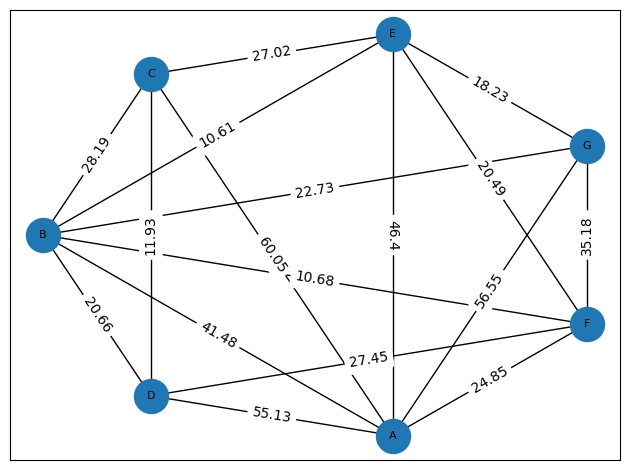

```python
graph.visualize_graph(Graf)
```

## Pencarian Rute Optimal (Total Cost)

```python
# code here A - G
graph.get_total(Graf, source = 'A', target = 'G', cutoff = 2)
```

|  | route | total |
| --- | --- | --- |
| 3 | [A, G] | 56.55 |
| 1 | [A, F, G] | 60.03 |
| 0 | [A, B, G] | 64.21 |
| 2 | [A, E, G] | 64.63 |

kita menggunakan cutoff bernilai 2 karna berdasarkan bisnisnya truk mampu mengangkut produk dengan berat maksimal 2,2 ton , kebutuhan produk perminggu setiap lokasi hanya 1 ton.

```python
# Code here
graph.get_total(Graf, source = 'A', target = 'E', cutoff = 2)
```

|  | route | total |
| --- | --- | --- |
| 1 | [A, F, E] | 45.34 |
| 2 | [A, E] | 46.40 |
| 0 | [A, B, E] | 52.09 |
| 4 | [A, G, E] | 74.78 |
| 3 | [A, C, E] | 87.07 |

```python
graph.get_total(Graf, source = 'A', target = 'D', cutoff = 2)
```

|  | route | total |
| --- | --- | --- |
| 1 | [A, F, D] | 52.30 |
| 3 | [A, D] | 55.13 |
| 0 | [A, B, D] | 62.14 |
| 2 | [A, C, D] | 71.98 |

```python
graph.get_total(Graf, source = 'A', target = 'C', cutoff = 2)
```

|  | route | total |
| --- | --- | --- |
| 2 | [A, C] | 60.05 |
| 3 | [A, D, C] | 67.06 |
| 0 | [A, B, C] | 69.67 |
| 1 | [A, E, C] | 73.42 |

```python
60.03 + 67.06 + 52.09
```

```
179.18
```

```python
64.21 + 45.34 + 67.06
```

```
176.61
```

Dari sini dapat disimpulan bahwa Rute Optimal yaitu :

Optional 1:

- A-F-G : Rp. 60.030
- A-D-C : Rp. 67.060
- A-B-E : Rp. 52.090

Total Rp. 179.180

Optional 2:

- A-B-G : Rp. 64.210
- A-F-E : Rp. 45.340
- A-D-C : Rp. 67.060

Total Rp. 176.610

Mari kita bandingkan dengan perspektif bisnis , mari kita bandingkan rute yang baru dengan yang lama

```python
# Membandingkan harga
aggcost = df_rec.pivot_table(index = 'weekofyear',
                    values = 'total',
                    aggfunc= 'sum').reset_index()

aggcost
```

|  | weekofyear | total |
| --- | --- | --- |
| 0 | 14 | 57.014828 |
| 1 | 15 | 35.531884 |
| 2 | 16 | 199.368149 |
| 3 | 17 | 215.321762 |
| 4 | 18 | 195.598888 |

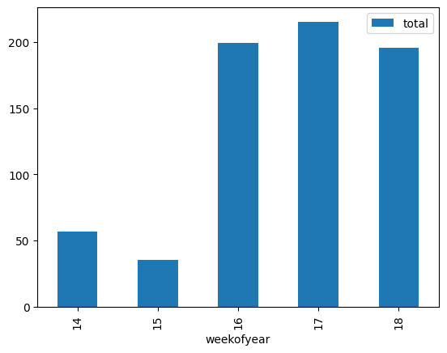

```python
aggcost.plot(x='weekofyear',kind = 'bar');
```

```python
df_rec[df_rec['weekofyear'] == 18]
```

|  | start | end | lokasi_start | latitude_start | longitude_start | lokasi_end | latitude_end | longitude_end | dist | lge/100km | ... | end_time | day | month_name | week_period | weekofyear | literneed | cost_fuel | time | cost_refri | total |
| --- | --- | --- | --- | --- | --- | --- | --- | --- | --- | --- | --- | --- | --- | --- | --- | --- | --- | --- | --- | --- | --- |
| 0 | B | D | Nipah Mall | -5.138213 | 119.450386 | Mall Ratu Indah | -5.152877 | 119.417858 | 7.5 | 15.08 | ... | 2023-05-03 15:45:00 | Wednesday | May | 2023-05-01/2023-05-07 | 18 | 1.13100 | 16.908450 | 25.0 | 3.75 | 20.658450 |
| 1 | A | B | Warehouse | -5.094272 | 119.491642 | Nipah Mall | -5.138213 | 119.450386 | 11.0 | 13.52 | ... | 2023-05-03 14:44:00 | Wednesday | May | 2023-05-01/2023-05-07 | 18 | 1.48720 | 22.233640 | 25.0 | 3.75 | 41.483640 |
| 2 | F | G | Makassar Town Square | -5.139702 | 119.473848 | Phinisi Point | -5.151032 | 119.404404 | 12.3 | 16.03 | ... | 2023-05-02 15:48:00 | Tuesday | May | 2023-05-01/2023-05-07 | 18 | 1.97169 | 29.476766 | 38.0 | 5.70 | 35.176766 |
| 3 | A | F | Warehouse | -5.094272 | 119.491642 | Makassar Town Square | -5.139702 | 119.473848 | 9.7 | 14.45 | ... | 2023-05-02 14:39:00 | Tuesday | May | 2023-05-01/2023-05-07 | 18 | 1.40165 | 20.954667 | 26.0 | 3.90 | 24.854667 |
| 4 | E | C | Mall Panakkukang | -5.156903 | 119.446034 | TSM Makassar | -5.158039 | 119.394943 | 9.8 | 15.27 | ... | 2023-05-01 15:33:00 | Monday | May | 2023-05-01/2023-05-07 | 18 | 1.49646 | 22.372077 | 31.0 | 4.65 | 27.022077 |
| 5 | A | E | Warehouse | -5.094272 | 119.491642 | Mall Panakkukang | -5.156903 | 119.446034 | 14.2 | 12.72 | ... | 2023-05-01 14:28:00 | Monday | May | 2023-05-01/2023-05-07 | 18 | 1.80624 | 27.003288 | 26.0 | 3.90 | 46.403288 |

6 rows × 22 columns

Dikarenakan rute yang lengkap adalah rute 3 minggu terakhir. Maka kita hanya dapat membandingkan rute rekomendasi dengan 3 minggu terakhir. kita akan menggunakan metode mean atau rata-rata

```python
new_route = pd.DataFrame({'rute': ["[A B G]", "[A F E]", "[A D C]"],
                        'cost': [64.21, 45.34, 67.06]})

new_route
```

|  | rute | cost |
| --- | --- | --- |
| 0 | [A B G] | 64.21 |
| 1 | [A F E] | 45.34 |
| 2 | [A D C] | 67.06 |

```python
cost_new_rute=new_route['cost'].sum().round()
cost_new_rute
```

```
177.0
```

```python
aggcost.reset_index()
```

|  | weekofyear | total |
| --- | --- | --- |
| 0 | 14 | 57.014828 |
| 1 | 15 | 35.531884 |
| 2 | 16 | 199.368149 |
| 3 | 17 | 215.321762 |
| 4 | 18 | 195.598888 |

```python
cost_current=aggcost[aggcost['weekofyear'].isin([16,17,18])]['total'].mean().round().astype(int)

print(f"Total cost rute baru adalah Rp{cost_current},000")
```

[output not shown]

```python
print(f"Jika kita bandingkan rute lama kita dengan rute baru , terjadi deviasi sebesar Rp{cost_current-cost_new_rute}00")
```

```
Jika kita bandingkan rute lama kita dengan rute baru , terjadi deviasi sebesar Rp26.000
```

# Visualisasi Rute Baru

```python
new_route
```

|  | rute | cost |
| --- | --- | --- |
| 0 | [A B G] | 64.21 |
| 1 | [A F E] | 45.34 |
| 2 | [A D C] | 67.06 |

```python
data = [['A', 'B', 'Monday'],
       ['B', 'G', 'Monday'],
       ['A', 'F', 'Tuesday'],
       ['F', 'E', 'Tuesday'],
       ['A', 'D', 'Wednesday'],
       ['D', 'C', 'Wednesday']]

optimize = pd.DataFrame(data, columns = ['start', 'end', 'day'])

optimize
```

|  | start | end | day |
| --- | --- | --- | --- |
| 0 | A | B | Monday |
| 1 | B | G | Monday |
| 2 | A | F | Tuesday |
| 3 | F | E | Tuesday |
| 4 | A | D | Wednesday |
| 5 | D | C | Wednesday |

```python
df_loc
```

|  | kode | lokasi | latitude | longitude |
| --- | --- | --- | --- | --- |
| 0 | A | Warehouse | -5.094272 | 119.491642 |
| 1 | B | Nipah Mall | -5.138213 | 119.450386 |
| 2 | C | TSM Makassar | -5.158039 | 119.394943 |
| 3 | D | Mall Ratu Indah | -5.152877 | 119.417858 |
| 4 | E | Mall Panakkukang | -5.156903 | 119.446034 |
| 5 | F | Makassar Town Square | -5.139702 | 119.473848 |
| 6 | G | Phinisi Point | -5.151032 | 119.404404 |

```python
opt_merge=optimize.merge(df_loc, how='left', left_on=['start'], right_on=['kode'])
opt_merge=opt_merge.merge(df_loc, how='left', left_on=['end'], right_on=['kode'], suffixes=('_start','_end'))
opt_merge
```

|  | start | end | day | kode_start | lokasi_start | latitude_start | longitude_start | kode_end | lokasi_end | latitude_end | longitude_end |
| --- | --- | --- | --- | --- | --- | --- | --- | --- | --- | --- | --- |
| 0 | A | B | Monday | A | Warehouse | -5.094272 | 119.491642 | B | Nipah Mall | -5.138213 | 119.450386 |
| 1 | B | G | Monday | B | Nipah Mall | -5.138213 | 119.450386 | G | Phinisi Point | -5.151032 | 119.404404 |
| 2 | A | F | Tuesday | A | Warehouse | -5.094272 | 119.491642 | F | Makassar Town Square | -5.139702 | 119.473848 |
| 3 | F | E | Tuesday | F | Makassar Town Square | -5.139702 | 119.473848 | E | Mall Panakkukang | -5.156903 | 119.446034 |
| 4 | A | D | Wednesday | A | Warehouse | -5.094272 | 119.491642 | D | Mall Ratu Indah | -5.152877 | 119.417858 |
| 5 | D | C | Wednesday | D | Mall Ratu Indah | -5.152877 | 119.417858 | C | TSM Makassar | -5.158039 | 119.394943 |

```python
# Visualisasi
graph.visualize_route(map_df, opt_merge)
```

Make this Notebook Trusted to load map: File -> Trust Notebook

[interactive chart not shown]

Make this Notebook Trusted to load map: File -> Trust Notebook

[interactive chart not shown]

Make this Notebook Trusted to load map: File -> Trust Notebook

[interactive chart not shown]

jika kita bandingkan dengan rute pada week sebelumnya

```python
graph.visualize_route(map_df, week18)
```

Make this Notebook Trusted to load map: File -> Trust Notebook

[interactive chart not shown]

Make this Notebook Trusted to load map: File -> Trust Notebook

[interactive chart not shown]

Make this Notebook Trusted to load map: File -> Trust Notebook

[interactive chart not shown]

Jadi dari permasalahan bisnis pada data ini, kita bisa memberikan rekomendasi rute terbaik berdasakan bobot yang menjadi perhatian perusahaan.